# Analysis of Cholera Cases

Binh, Brandon, Carter, Marika

11/13/2022

## Dynamic paragraph

Our Cholera analysis shows that the country with the most cases is Haiti, in which 23.9% of people wash their hands and 23.3% of people practice open defecation. The country with the most deaths is India, in which 67% of people wash their hands and 51.7% of people practice open defecation. This observation also draws questions about equal healthcare, and how cholera is being treated. Among the top 5 of each variable are, in order; for deaths: India, Indonesia, Democratic Republic of the Congo, Nigeria, United Republic of Tanzania, and for cases: Haiti, Peru, Democratic Republic of the Congo, India, Indonesia.

## Charts

We included this chart because we wanted to know and visualize the connection between the recorded cholera deaths and the availability of public medicine in countries that have records on their cholera information. This chart looks at the correlation between the two factors from the year 2007 to 2013. From this chart we can see that when a country has low accessibility to publicly available medicine, the total cholera caused deaths are very high. Although this chart is only looking at total deaths and medicine availability, not including other factors such as geographical location or advanced medicine accessibility, we can still get a better understanding of the correlation.

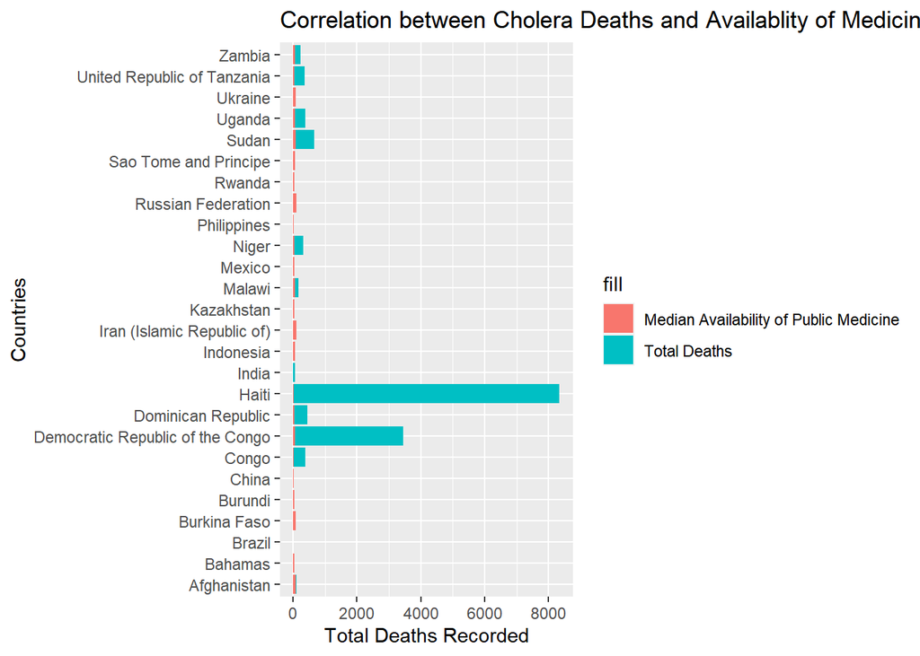

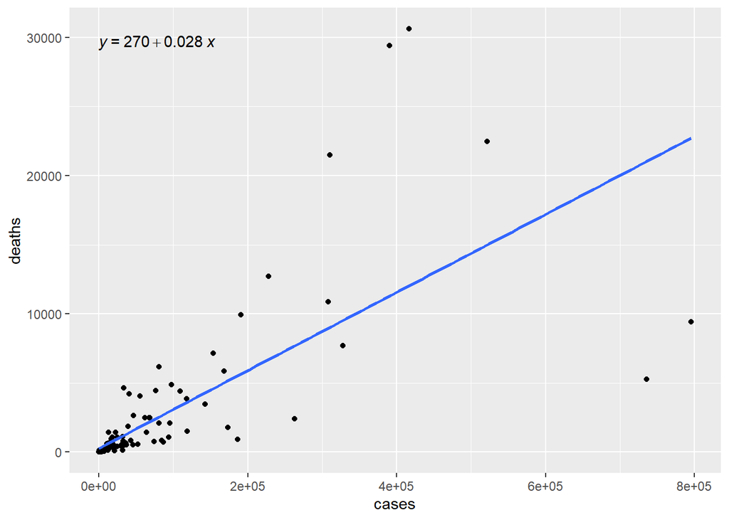

We were interested in exploring the relationship between hygiene and cholera cases which we attributed to handwashing rates in urban and rural areas of countries. We decided to map out places where there were high levels of cholera cases with relation to the percentage of populations with adequate hand washing stations at home. The handwashing dataset contains data from 2000-2020, allowing us to compare changes in cholera characteristics over time. Some of the limitations we came across in trying to compile this graph were the fact that there were some countries that didn’t have any statistics on handwashing which made it difficult to compare to other countries.

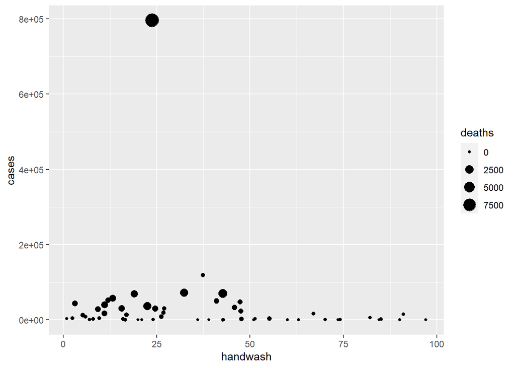

## Summary Information Table

The following table contains the aggregated data used in the charts. The cases and deaths columns are the sum total of cholera cases and deaths in the countries, while handwashing and defecation are, on average, what percent of people in that country say that they wash their hands or practice open defecation. An entry of NaN means that no data was collected in that particular country.

| Country | cases | deaths | handwashing | defecation |
| --- | --- | --- | --- | --- |
| Afghanistan | 262738 | 2387 | 37.4 | 19.6 |
| Albania | 626 | 25 | NaN | NaN |
| Algeria | 12729 | 650 | NaN | 4.0 |
| Angola | 191036 | 9920 | 26.2 | 28.9 |
| Argentina | 4550 | 67 | NaN | NaN |
| Armenia | 25 | 0 | NaN | NaN |
| Australia | 127 | 0 | NaN | 0.0 |
| Austria | 9 | 0 | NaN | 0.0 |
| Azerbaijan | 18 | 0 | NaN | NaN |
| Bahamas | 2 | 0 | NaN | 0.0 |
| Bahrain | 1064 | 6 | NaN | 0.0 |
| Bangladesh | 54980 | 4056 | NaN | 17.0 |
| Belarus | 6 | 0 | NaN | NaN |
| Belgium | 10 | 0 | NaN | 0.0 |
| Belize | 387 | 10 | NaN | NaN |
| Benin | 31581 | 1108 | 5.3 | 61.3 |
| Bhutan | 960 | 25 | NaN | NaN |
| Bolivia (Plurinational State of) | 42548 | 854 | NaN | NaN |
| Botswana | 23 | 3 | NaN | 17.8 |
| Brazil | 173220 | 1774 | NaN | 6.8 |
| Brunei Darussalam | 126 | 0 | NaN | 3.0 |
| Burkina Faso | 12707 | 1424 | 8.0 | 63.0 |
| Burundi | 35219 | 782 | 6.0 | 3.0 |
| Cabo Verde | 14144 | 284 | NaN | 40.5 |
| Cambodia | 16965 | 945 | 63.0 | 60.7 |
| Cameroon | 76422 | 4431 | 36.0 | 7.0 |
| Canada | 81 | 1 | NaN | 0.0 |
| Central African Republic | 923 | 141 | 16.6 | 23.8 |
| Chad | 80846 | 6170 | 15.6 | 69.2 |
| Chile | 180 | 5 | NaN | 1.0 |

[output cut: 131 more lines]